# Answers to exercises

### Boxplots:

Having generated the combined `data.frame`, `ggplot2` is used to actually build the plot.

```r
mrged_df <- merge(div_rare, analyses_metadata, by = 0, all.y = F)
head(mrged_df)
```

A data.frame: 6 × 69

| Row.names <I<chr>> | Observed <dbl> | Chao1 <dbl> | se.chao1 <dbl> | ACE <dbl> | se.ACE <dbl> | Shannon <dbl> | Simpson <dbl> | InvSimpson <dbl> | Fisher <dbl> | ⋯ | sample_environment (feature) <chr> | sample_environment (material) <chr> | sample_environmental package <chr> | sample_target gene <chr> | sample_sequencing method <chr> | sample_geographic location (latitude) <chr> | sample_instrument model <chr> | sample_acc_type <chr> | run_accession <chr> | biome_string <chr> |
| --- | --- | --- | --- | --- | --- | --- | --- | --- | --- | --- | --- | --- | --- | --- | --- | --- | --- | --- | --- | --- |
| MGYA00194719 | 246 | 303.3030 | 19.212054 | 307.0712 | 8.934434 | 3.067228 | 0.9059006 | 10.62706 | 35.86796 | ⋯ | anaerobic sludge | anaerobic digester sludge | miscellaneous natural or artificial environment | NA | pyrosequencing | 50.9339 | Illumina MiSeq | samples | ERR2710127 | root:Engineered:Biogas plant:Wet fermentation |
| MGYA00194720 | 230 | 301.5500 | 26.477252 | 287.6986 | 8.605116 | 3.500172 | 0.9365899 | 15.77035 | 33.15525 | ⋯ | anaerobic sludge | anaerobic digester sludge | miscellaneous natural or artificial environment | NA | pyrosequencing | 50.9339 | Illumina MiSeq | samples | ERR2710145 | root:Engineered:Biogas plant:Wet fermentation |
| MGYA00194721 | 237 | 290.6364 | 18.253908 | 296.3886 | 8.940810 | 3.337150 | 0.9367027 | 15.79845 | 34.33759 | ⋯ | anaerobic sludge | anaerobic digester sludge | miscellaneous natural or artificial environment | NA | pyrosequencing | 50.9339 | Illumina MiSeq | samples | ERR2710147 | root:Engineered:Biogas plant:Wet fermentation |
| MGYA00194722 | 255 | 277.5238 | 9.028302 | 288.2875 | 8.407985 | 3.276989 | 0.9320910 | 14.72559 | 37.40946 | ⋯ | anaerobic sludge | anaerobic digester sludge | miscellaneous natural or artificial environment | NA | pyrosequencing | 50.9339 | Illumina MiSeq | samples | ERR2710133 | root:Engineered:Biogas plant:Wet fermentation |
| MGYA00194723 | 230 | 315.0385 | 28.119584 | 324.1711 | 9.817270 | 3.210095 | 0.9278632 | 13.86256 | 33.15525 | ⋯ | anaerobic sludge | anaerobic digester sludge | miscellaneous natural or artificial environment | NA | pyrosequencing | 50.9339 | Illumina MiSeq | samples | ERR2710148 | root:Engineered:Biogas plant:Wet fermentation |
| MGYA00194724 | 239 | 298.0000 | 20.178025 | 303.8485 | 8.947395 | 3.421479 | 0.9287415 | 14.03342 | 34.67668 | ⋯ | anaerobic sludge | anaerobic digester sludge | miscellaneous natural or artificial environment | NA | pyrosequencing | 50.9339 | Illumina MiSeq | samples | ERR2710137 | root:Engineered:Biogas plant:Wet fermentation |

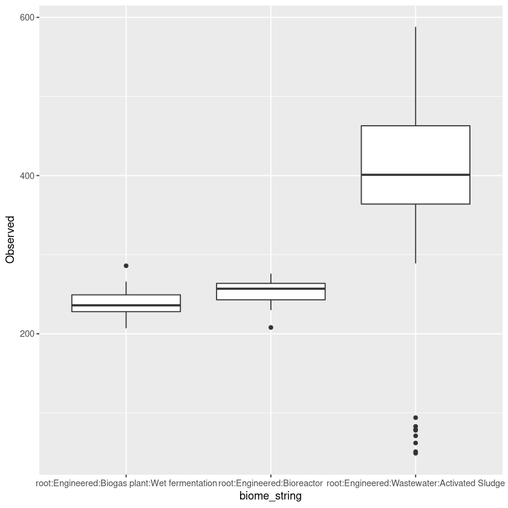

```r
library(ggplot2)
ggplot(mrged_df, aes(x=biome_string, y=Observed)) + geom_boxplot()
```

Clearly there is a higher diversity in the aerobic activate sludge samples than the anaerobic digester samples. Just to check it's not an artifact of the sampling process, we can check the raw read ranges of the samples (see below). And reassuringly, there's not a lot of difference between the sample types in terms of total read counts per sample.

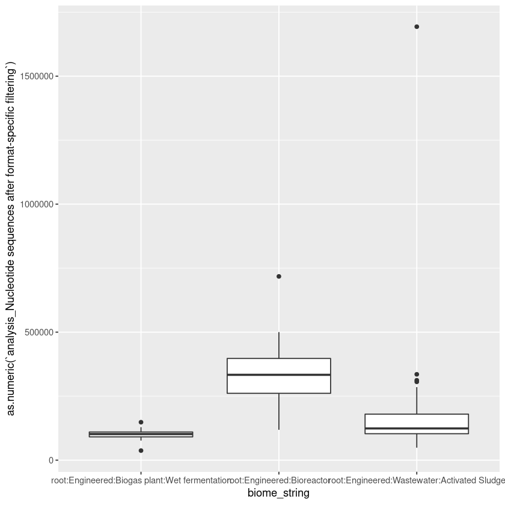

```r
ggplot(mrged_df, aes_string(x="biome_string", y="as.numeric(`analysis_Nucleotide sequences after format-specific filtering`)")) + geom_boxplot()
```

## Ordination

Generating the ordination plot is pretty easy as well, once you know what you're doing. `metaMDS` from `vegan` expects a community matrix with samples as rows and taxa as columns, so a transpose (`t`) is required to flip the OTU table.

`merge` is again used to join the ordination results with the sample metadata, only this time for illustrative purposes we subset the metadata prior to merging, and specify "`row.names`" and "`analysis_accession`" instead of `by=0`. Either (and more) ways are perfectly legitimate ways to do this.

Finally, `ggplot2` is used (again) to plot the points, coloured by the biome type.

```r
library(vegan)
nmds_res <- metaMDS(t(otu_table(ps_rare)), distance = "bray")
```

```
Square root transformation
Wisconsin double standardization
*** Solution reached
```

```r
head(nmds_res$points)
```

A matrix: 6 × 2 of type dbl

|  | MDS1 | MDS2 |
| --- | --- | --- |
| MGYA00200523 | -9.292517 | -34.8469896 |
| MGYA00200524 | 12.421617 | 0.9775491 |
| MGYA00200525 | 12.632811 | 1.0725489 |
| MGYA00200526 | 12.459230 | 0.3354338 |
| MGYA00200527 | 12.358269 | 1.1107789 |
| MGYA00200528 | 12.480058 | 0.9699585 |

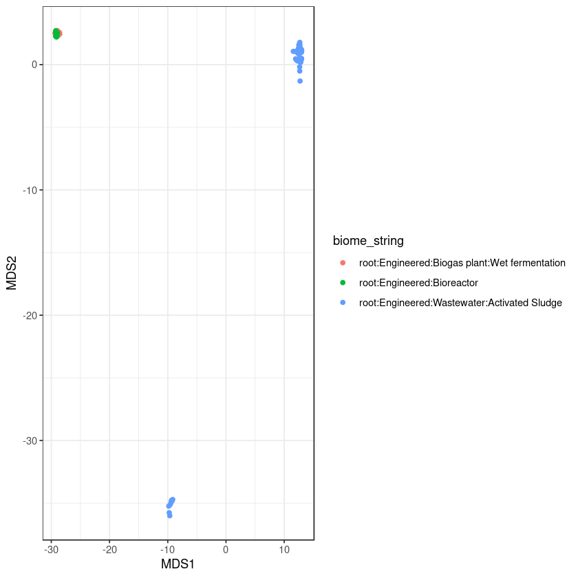

```r
results_df <-  merge(nmds_res$points,
                     analyses_metadata[,c("analysis_accession","biome_string")],
                     by.x="row.names", by.y="analysis_accession")

ggplot(results_df, aes(x=MDS1, y=MDS2)) + geom_point(aes_string(color="`biome_string`")) + theme_bw()
```

It's not the clearest graph to read, there's clearly good seperation between the two sample types. There's also an obvious set of outlier activate sludge samples (bottom of the plot) which might be interesting to investigate further.

### Functional data

Just as easy as the `phyloseq` data, we first grab the analysis accessions for study MGYS00003598, then use those to retrieve the metadata set.

```r
analysis_accessions <- mgnify_analyses_from_studies(mg, "MGYS00003598")
func_data <- mgnify_get_analyses_metadata(mg, analysis_accessions)
```

```r
head(func_data)
```

A data.frame: 6 × 48

|  | analysis_experiment-type <chr> | analysis_pipeline-version <chr> | analysis_accession <chr> | analysis_analysis-status <chr> | analysis_complete-time <chr> | analysis_instrument-platform <chr> | analysis_instrument-model <chr> | analysis_Contigs with InterProScan match <chr> | analysis_Contigs with predicted CDS <chr> | analysis_Contigs with predicted RNA <chr> | ⋯ | sample_host-tax-id <chr> | sample_species <chr> | sample_last-update <chr> | sample_host taxid <chr> | sample_instrument model <chr> | sample_last update date <chr> | sample_host scientific name <chr> | sample_acc_type <chr> | assembly_accession <chr> | biome_string <chr> |
| --- | --- | --- | --- | --- | --- | --- | --- | --- | --- | --- | --- | --- | --- | --- | --- | --- | --- | --- | --- | --- | --- |
| MGYA00510848 | assembly | 5.0 | MGYA00510848 | completed | 2020-06-17T22:07:56 | ILLUMINA | Illumina HiSeq 2000 | 5756 | 11672 | 538 | ⋯ | 9606 | Homo sapiens | 2020-05-19T14:37:26 | 9606 | Illumina HiSeq 2000 | 2016-03-29 | Homo sapiens | samples | ERZ501067 | root:Host-associated:Human:Skin |
| MGYA00510849 | assembly | 5.0 | MGYA00510849 | completed | 2020-06-17T22:07:50 | ILLUMINA | Illumina HiSeq 2000 | 2576 | 4701 | 264 | ⋯ | 9606 | Homo sapiens | 2020-05-19T14:40:48 | 9606 | Illumina HiSeq 2000 | 2016-03-29 | Homo sapiens | samples | ERZ501066 | root:Host-associated:Human:Skin |
| MGYA00510850 | assembly | 5.0 | MGYA00510850 | completed | 2020-06-17T22:07:47 | ILLUMINA | Illumina HiSeq 2000 | 6865 | 9563 | 296 | ⋯ | 9606 | Homo sapiens | 2020-05-19T14:41:52 | 9606 | Illumina HiSeq 2000 | 2016-03-29 | Homo sapiens | samples | ERZ501065 | root:Host-associated:Human:Skin |
| MGYA00510851 | assembly | 5.0 | MGYA00510851 | completed | 2020-06-17T22:07:44 | ILLUMINA | Illumina HiSeq 2000 | 21871 | 26991 | 559 | ⋯ | 9606 | Homo sapiens | 2020-05-19T14:43:36 | 9606 | Illumina HiSeq 2000 | 2016-03-29 | Homo sapiens | samples | ERZ501064 | root:Host-associated:Human:Skin |
| MGYA00510852 | assembly | 5.0 | MGYA00510852 | completed | 2020-06-17T22:07:40 | ILLUMINA | Illumina HiSeq 2000 | 7641 | 13094 | 560 | ⋯ | 9606 | Homo sapiens | 2020-05-19T14:45:54 | 9606 | Illumina HiSeq 2000 | 2016-03-29 | Homo sapiens | samples | ERZ501063 | root:Host-associated:Human:Skin |
| MGYA00510853 | assembly | 5.0 | MGYA00510853 | completed | 2020-06-17T22:07:36 | ILLUMINA | Illumina HiSeq 2000 | 2081 | 3852 | 226 | ⋯ | 9606 | Homo sapiens | 2020-05-19T14:47:17 | 9606 | Illumina HiSeq 2000 | 2016-03-29 | Homo sapiens | samples | ERZ501062 | root:Host-associated:Human:Skin |

The `dim` function returns the dimensions (num rows, num columns) of a matrix or data.frame

```r
dim(func_data)
```

1. 188

2. 48

Using table, we see that each `sample` is included twice in the metadata. The reason is that the analysis has been run twice, with 2 different pipeline versions:

```r
table(func_data$sample_accession)
```

```
SRS892003 SRS892004 SRS892005 SRS892006 SRS892007 SRS892008 SRS892009 SRS892010
        2         2         2         2         2         2         2         2
SRS892011 SRS892012 SRS892013 SRS892014 SRS892015 SRS892016 SRS892017 SRS892018
        2         2         2         2         2         2         2         2
SRS892019 SRS892020 SRS892021 SRS892022 SRS892023 SRS892024 SRS892025 SRS892026
        2         2         2         2         2         2         2         2
SRS892027 SRS892028 SRS892029 SRS892030 SRS892031 SRS892032 SRS892033 SRS892034
        2         2         2         2         2         2         2         2
SRS892035 SRS892036 SRS892037 SRS892038 SRS892039 SRS892040 SRS892041 SRS892042
        2         2         2         2         2         2         2         2
SRS892043 SRS892044 SRS892045 SRS892046 SRS892047 SRS892048 SRS892049 SRS892050
        2         2         2         2         2         2         2         2
SRS892051 SRS892052 SRS892053 SRS892054 SRS892055 SRS892056 SRS892057 SRS892058
        2         2         2         2         2         2         2         2
SRS892059 SRS892060 SRS892061 SRS892062 SRS892063 SRS892064 SRS892065 SRS892066
        2         2         2         2         2         2         2         2
SRS892067 SRS892068 SRS892069 SRS892070 SRS892071 SRS892072 SRS892073 SRS892074
        2         2         2         2         2         2         2         2
SRS892075 SRS892076 SRS892077 SRS892078 SRS892079 SRS892080 SRS892081 SRS892082
        2         2         2         2         2         2         2         2
SRS892083 SRS892084 SRS892085 SRS892088 SRS892089 SRS892091 SRS892092 SRS892095
        2         2         2         2         2         2         2         2
SRS892096 SRS892099 SRS892100 SRS892103 SRS892104 SRS892107
        2         2         2         2         2         2
```

```r
table(func_data$`analysis_pipeline-version`)
```

```
4.1 5.0
 94  94
```

While not imposed by MGnifyR, it probably makes sense to limit the investigation to a single version of the pipeline. Hence the first line below. The remaining 2 lines pull out the row where the predicted CDS count is equal to the maximum of the whole column.

```r
func_data <- func_data[func_data$`analysis_pipeline-version` == "5.0",]
vec=as.numeric(func_data$`analysis_Predicted CDS`)
func_data[vec==max(vec),]
```

A data.frame: 1 × 48

|  | analysis_experiment-type <chr> | analysis_pipeline-version <chr> | analysis_accession <chr> | analysis_analysis-status <chr> | analysis_complete-time <chr> | analysis_instrument-platform <chr> | analysis_instrument-model <chr> | analysis_Contigs with InterProScan match <chr> | analysis_Contigs with predicted CDS <chr> | analysis_Contigs with predicted RNA <chr> | ⋯ | sample_host-tax-id <chr> | sample_species <chr> | sample_last-update <chr> | sample_host taxid <chr> | sample_instrument model <chr> | sample_last update date <chr> | sample_host scientific name <chr> | sample_acc_type <chr> | assembly_accession <chr> | biome_string <chr> |
| --- | --- | --- | --- | --- | --- | --- | --- | --- | --- | --- | --- | --- | --- | --- | --- | --- | --- | --- | --- | --- | --- |
| MGYA00510855 | assembly | 5.0 | MGYA00510855 | completed | 2020-06-17T22:07:28 | ILLUMINA | Illumina HiSeq 2000 | 17889 | 109866 | 6552 | ⋯ | 9606 | Homo sapiens | 2020-05-19T14:50:28 | 9606 | Illumina HiSeq 2000 | 2016-03-29 | Homo sapiens | samples | ERZ501060 | root:Host-associated:Human:Skin |

To retrieve the actual functional data, use `mgnify_get_analyses_results`.

```r
func_results <- mgnify_get_analyses_results(mg, func_data$analysis_accession, retrievelist = "go-slim")
```

As discussed, `mgnify_get_analyses_results` returns a named `list` of `data.frames`:

```r
goslim <- func_results$`go-slim`
```

As previously, searching for the minimum or maximum entry of a column or row is easy with data.frames. In this case, `rowMeans` is a handy helper function that does the same as a more complicated call to `apply`.

```r
rm <- rowMeans(goslim[,c(-1,-2,-3)])
goslim[rm == max(rm),]
```

A data.frame: 1 × 97

|  | accession <chr> | description <chr> | lineage <chr> | MGYA00510848 <int> | MGYA00510849 <int> | MGYA00510850 <int> | MGYA00510851 <int> | MGYA00510852 <int> | MGYA00510853 <int> | MGYA00510854 <int> | ⋯ | MGYA00510932 <int> | MGYA00510933 <int> | MGYA00510934 <int> | MGYA00510935 <int> | MGYA00510936 <int> | MGYA00510937 <int> | MGYA00510938 <int> | MGYA00510939 <int> | MGYA00510940 <int> | MGYA00514416 <int> |
| --- | --- | --- | --- | --- | --- | --- | --- | --- | --- | --- | --- | --- | --- | --- | --- | --- | --- | --- | --- | --- | --- |
| 4 | GO:0000166 | nucleotide binding | molecular_function | 887 | 760 | 1513 | 3775 | 1316 | 632 | 3108 | ⋯ | 1631 | 1194 | 1417 | 2212 | 2789 | 1567 | 3090 | 2144 | 3914 | 2633 |

We use the same function to retrieve Interpro identifiers too, except this time we specify a single accession rather than the full vector. This is only because of time limitations though. MGnifyR will happily retrieve as many results as you want (memory permitting), it's just that iInterpro results in particular can be slow to download.

```r
ipres  <- mgnify_get_analyses_results(mg, "MGYA00510855", retrievelist = "interpro-identifiers")$`interpro-identifiers`
```

```r
head(ipres)
```

A data.frame: 6 × 3

| accession <chr> | description <chr> | MGYA00510855 <int> |
| --- | --- | --- |
| IPR000001 | Kringle | 4 |
| IPR000008 | C2 domain | 15 |
| IPR000009 | Protein phosphatase 2A regulatory subunit PR55 | 3 |
| IPR000010 | Cystatin domain | 3 |
| IPR000011 | Ubiquitin/SUMO-activating enzyme E1 | 5 |
| IPR000014 | PAS domain | 8 |

```r
ipres[ipres$MGYA00510855 == max(ipres$MGYA00510855),]
```

A data.frame: 1 × 3

|  | accession <chr> | description <chr> | MGYA00510855 <int> |
| --- | --- | --- | --- |
| 7382 | IPR036388 | Winged helix-like DNA-binding domain superfamily | 590 |

# Downloads

Downloading larger files through `MGnifyR` is a 2 step process. Firstly, use `mgnify_get_download_urls` to retrieve the available download metadata. Note that you need to supply an `accession_type` parameter as well as this time it's not just `analyses` that may be searched.

```r
all_dls <- mgnify_get_download_urls(mg, func_data$analysis_accession, accession_type = "analyses")
```

```r
head(all_dls)
```

A data.frame: 6 × 17

| type <chr> | id <chr> | attributes.alias <chr> | attributes.file.format.name <chr> | attributes.file.format.compression <lgl> | attributes.file.format.extension <chr> | attributes.description.description <chr> | attributes.description.label <chr> | attributes.group.type <chr> | attributes.file.checksum.checksum <chr> | attributes.file.checksum.checksum.algorithm <chr> | relationships.pipeline.related <chr> | relationships.pipeline.data.type <chr> | relationships.pipeline.data.id <chr> | download_url <chr> | accession <chr> | accession_type <chr> |
| --- | --- | --- | --- | --- | --- | --- | --- | --- | --- | --- | --- | --- | --- | --- | --- | --- |
| analysis-job-downloads | ERZ501067_FASTA.fasta.gz | ERZ501067_FASTA.fasta.gz | FASTA | TRUE | fasta | Processed contigs | Processed contigs | Sequence data |  |  | https://www.ebi.ac.uk/metagenomics/api/v1/pipelines/5.0?format=json | pipelines | 5.0 | https://www.ebi.ac.uk/metagenomics/api/v1/analyses/MGYA00510848/file/ERZ501067_FASTA.fasta.gz | MGYA00510848 | analyses |
| analysis-job-downloads | ERZ501067_FASTA_predicted_cds.faa.gz | ERZ501067_FASTA_predicted_cds.faa.gz | FASTA | TRUE | fasta | All predicted CDS | Predicted CDS (aa) | Sequence data |  |  | https://www.ebi.ac.uk/metagenomics/api/v1/pipelines/5.0?format=json | pipelines | 5.0 | https://www.ebi.ac.uk/metagenomics/api/v1/analyses/MGYA00510848/file/ERZ501067_FASTA_predicted_cds.faa.gz | MGYA00510848 | analyses |
| analysis-job-downloads | ERZ501067_FASTA_predicted_orf.ffn.gz | ERZ501067_FASTA_predicted_orf.ffn.gz | FASTA | TRUE | fasta | All predicted ORF | Predicted ORF (nt) | Sequence data |  |  | https://www.ebi.ac.uk/metagenomics/api/v1/pipelines/5.0?format=json | pipelines | 5.0 | https://www.ebi.ac.uk/metagenomics/api/v1/analyses/MGYA00510848/file/ERZ501067_FASTA_predicted_orf.ffn.gz | MGYA00510848 | analyses |
| analysis-job-downloads | ERZ501067_FASTA_annotations.gff.bgz | ERZ501067_FASTA_annotations.gff.bgz | GFF | TRUE | gff | Combined (eggNOG, InterPro, antiSMASH) annotation | Combined (eggNOG, InterPro, antiSMASH) annotation | Functional analysis |  |  | https://www.ebi.ac.uk/metagenomics/api/v1/pipelines/5.0?format=json | pipelines | 5.0 | https://www.ebi.ac.uk/metagenomics/api/v1/analyses/MGYA00510848/file/ERZ501067_FASTA_annotations.gff.bgz | MGYA00510848 | analyses |
| analysis-job-downloads | ERZ501067_FASTA_diamond.tsv.gz | ERZ501067_FASTA_diamond.tsv.gz | TSV | TRUE | tsv | Diamond annotation | Diamond annotation | Functional analysis |  |  | https://www.ebi.ac.uk/metagenomics/api/v1/pipelines/5.0?format=json | pipelines | 5.0 | https://www.ebi.ac.uk/metagenomics/api/v1/analyses/MGYA00510848/file/ERZ501067_FASTA_diamond.tsv.gz | MGYA00510848 | analyses |
| analysis-job-downloads | ERZ501067_FASTA_emapper.annotations.tsv.gz | ERZ501067_FASTA_emapper.annotations.tsv.gz | TSV | TRUE | tsv | eggNOG annotations of the protein coding sequences | eggNOG annotation | Functional analysis |  |  | https://www.ebi.ac.uk/metagenomics/api/v1/pipelines/5.0?format=json | pipelines | 5.0 | https://www.ebi.ac.uk/metagenomics/api/v1/analyses/MGYA00510848/file/ERZ501067_FASTA_emapper.annotations.tsv.gz | MGYA00510848 | analyses |

As with other the other return types, the columns in and available downloads result data.frame can be a bit unwieldy, but the names should be pretty self explanatory.

```r
table(all_dls$attributes.description.description)
```

```
                                      All contigs encoding LSU rRNA
                                                                 94
                                      All contigs encoding SSU rRNA
                                                                 94
                                                  All predicted CDS
                                                                 94
                                                  All predicted ORF
                                                                 94
                                               antiSMASH annotation
                                                                282
                                                  antiSMASH summary
                                                                 94
                  Combined (eggNOG, InterPro, antiSMASH) annotation
                                                                 94
                                             Complete GO annotation
                                                                 94
                                           Complete Pfam annotation
                                                                 94
                                                 Diamond annotation
                                                                 94
                 eggNOG annotations of the protein coding sequences
                                                                 94
                                       Genome Properties annotation
                                                                 94
                                                 GO slim annotation
                                                                 94
                                             InterPro matches (TSV)
                                                                 94
                                                   InterPro summary
                                                                 94
                                        KEGG orthologues annotation
                                                                 94
                                            KEGG pathway annotation
                                                                 94
                                   KEGG pathway annotation (contig)
                                                                 94
                                         MAPSeq output file for LSU
                                                                 94
                                         MAPSeq output file for SSU
                                                                 94
```

[output cut: 35 more lines]

```
                                                                 94
      Predicted Protozoan signal recognition particle RNA (RF01856)
                                                                 44
                                  Predicted RNase MRP RNA (RF00030)
                                                                 37
                    Predicted Selenocysteine transfer RNA (RF01852)
                                                                 94
                                   Predicted transfer RNA (RF00005)
                                                                 94
                         Predicted transfer-messenger RNA (RF00023)
                                                                 94
                                                  Processed contigs
                                                                 94
                TSV formatted file containing eggNOG seed orthologs
                                                                 94
```

```r
all_dls[all_dls$attributes.description.description == "antiSMASH annotation",]
```

A data.frame: 282 × 17

|  | type <chr> | id <chr> | attributes.alias <chr> | attributes.file.format.name <chr> | attributes.file.format.compression <lgl> | attributes.file.format.extension <chr> | attributes.description.description <chr> | attributes.description.label <chr> | attributes.group.type <chr> | attributes.file.checksum.checksum <chr> | attributes.file.checksum.checksum.algorithm <chr> | relationships.pipeline.related <chr> | relationships.pipeline.data.type <chr> | relationships.pipeline.data.id <chr> | download_url <chr> | accession <chr> | accession_type <chr> |
| --- | --- | --- | --- | --- | --- | --- | --- | --- | --- | --- | --- | --- | --- | --- | --- | --- | --- |
| 32 | analysis-job-downloads | ERZ501067_FASTA_antismash.embl.gz | ERZ501067_FASTA_antismash.embl.gz | EMBL | TRUE | embl | antiSMASH annotation | antiSMASH annotation | Pathways and Systems |  |  | https://www.ebi.ac.uk/metagenomics/api/v1/pipelines/5.0?format=json | pipelines | 5.0 | https://www.ebi.ac.uk/metagenomics/api/v1/analyses/MGYA00510848/file/ERZ501067_FASTA_antismash.embl.gz | MGYA00510848 | analyses |
| 33 | analysis-job-downloads | ERZ501067_FASTA_antismash.gbk.gz | ERZ501067_FASTA_antismash.gbk.gz | GenBank | TRUE | gbk | antiSMASH annotation | antiSMASH annotation | Pathways and Systems |  |  | https://www.ebi.ac.uk/metagenomics/api/v1/pipelines/5.0?format=json | pipelines | 5.0 | https://www.ebi.ac.uk/metagenomics/api/v1/analyses/MGYA00510848/file/ERZ501067_FASTA_antismash.gbk.gz | MGYA00510848 | analyses |
| 34 | analysis-job-downloads | ERZ501067_FASTA_antismash.gff.bgz | ERZ501067_FASTA_antismash.gff.bgz | GFF | TRUE | gff | antiSMASH annotation | antiSMASH annotation | Pathways and Systems |  |  | https://www.ebi.ac.uk/metagenomics/api/v1/pipelines/5.0?format=json | pipelines | 5.0 | https://www.ebi.ac.uk/metagenomics/api/v1/analyses/MGYA00510848/file/ERZ501067_FASTA_antismash.gff.bgz | MGYA00510848 | analyses |
| 72 | analysis-job-downloads | ERZ501066_FASTA_antismash.embl.gz | ERZ501066_FASTA_antismash.embl.gz | EMBL | TRUE | embl | antiSMASH annotation | antiSMASH annotation | Pathways and Systems |  |  | https://www.ebi.ac.uk/metagenomics/api/v1/pipelines/5.0?format=json | pipelines | 5.0 | https://www.ebi.ac.uk/metagenomics/api/v1/analyses/MGYA00510849/file/ERZ501066_FASTA_antismash.embl.gz | MGYA00510849 | analyses |
| 73 | analysis-job-downloads | ERZ501066_FASTA_antismash.gbk.gz | ERZ501066_FASTA_antismash.gbk.gz | GenBank | TRUE | gbk | antiSMASH annotation | antiSMASH annotation | Pathways and Systems |  |  | https://www.ebi.ac.uk/metagenomics/api/v1/pipelines/5.0?format=json | pipelines | 5.0 | https://www.ebi.ac.uk/metagenomics/api/v1/analyses/MGYA00510849/file/ERZ501066_FASTA_antismash.gbk.gz | MGYA00510849 | analyses |
| 74 | analysis-job-downloads | ERZ501066_FASTA_antismash.gff.bgz | ERZ501066_FASTA_antismash.gff.bgz | GFF | TRUE | gff | antiSMASH annotation | antiSMASH annotation | Pathways and Systems |  |  | https://www.ebi.ac.uk/metagenomics/api/v1/pipelines/5.0?format=json | pipelines | 5.0 | https://www.ebi.ac.uk/metagenomics/api/v1/analyses/MGYA00510849/file/ERZ501066_FASTA_antismash.gff.bgz | MGYA00510849 | analyses |
| 114 | analysis-job-downloads | ERZ501065_FASTA_antismash.embl.gz | ERZ501065_FASTA_antismash.embl.gz | EMBL | TRUE | embl | antiSMASH annotation | antiSMASH annotation | Pathways and Systems |  |  | https://www.ebi.ac.uk/metagenomics/api/v1/pipelines/5.0?format=json | pipelines | 5.0 | https://www.ebi.ac.uk/metagenomics/api/v1/analyses/MGYA00510850/file/ERZ501065_FASTA_antismash.embl.gz | MGYA00510850 | analyses |
| 115 | analysis-job-downloads | ERZ501065_FASTA_antismash.gbk.gz | ERZ501065_FASTA_antismash.gbk.gz | GenBank | TRUE | gbk | antiSMASH annotation | antiSMASH annotation | Pathways and Systems |  |  | https://www.ebi.ac.uk/metagenomics/api/v1/pipelines/5.0?format=json | pipelines | 5.0 | https://www.ebi.ac.uk/metagenomics/api/v1/analyses/MGYA00510850/file/ERZ501065_FASTA_antismash.gbk.gz | MGYA00510850 | analyses |
| 116 | analysis-job-downloads | ERZ501065_FASTA_antismash.gff.bgz | ERZ501065_FASTA_antismash.gff.bgz | GFF | TRUE | gff | antiSMASH annotation | antiSMASH annotation | Pathways and Systems |  |  | https://www.ebi.ac.uk/metagenomics/api/v1/pipelines/5.0?format=json | pipelines | 5.0 | https://www.ebi.ac.uk/metagenomics/api/v1/analyses/MGYA00510850/file/ERZ501065_FASTA_antismash.gff.bgz | MGYA00510850 | analyses |
| 162 | analysis-job-downloads | ERZ501064_FASTA_antismash.embl.gz | ERZ501064_FASTA_antismash.embl.gz | EMBL | TRUE | embl | antiSMASH annotation | antiSMASH annotation | Pathways and Systems |  |  | https://www.ebi.ac.uk/metagenomics/api/v1/pipelines/5.0?format=json | pipelines | 5.0 | https://www.ebi.ac.uk/metagenomics/api/v1/analyses/MGYA00510851/file/ERZ501064_FASTA_antismash.embl.gz | MGYA00510851 | analyses |
| 163 | analysis-job-downloads | ERZ501064_FASTA_antismash.gbk.gz | ERZ501064_FASTA_antismash.gbk.gz | GenBank | TRUE | gbk | antiSMASH annotation | antiSMASH annotation | Pathways and Systems |  |  | https://www.ebi.ac.uk/metagenomics/api/v1/pipelines/5.0?format=json | pipelines | 5.0 | https://www.ebi.ac.uk/metagenomics/api/v1/analyses/MGYA00510851/file/ERZ501064_FASTA_antismash.gbk.gz | MGYA00510851 | analyses |
| 164 | analysis-job-downloads | ERZ501064_FASTA_antismash.gff.bgz | ERZ501064_FASTA_antismash.gff.bgz | GFF | TRUE | gff | antiSMASH annotation | antiSMASH annotation | Pathways and Systems |  |  | https://www.ebi.ac.uk/metagenomics/api/v1/pipelines/5.0?format=json | pipelines | 5.0 | https://www.ebi.ac.uk/metagenomics/api/v1/analyses/MGYA00510851/file/ERZ501064_FASTA_antismash.gff.bgz | MGYA00510851 | analyses |
| 205 | analysis-job-downloads | ERZ501063_FASTA_antismash.embl.gz | ERZ501063_FASTA_antismash.embl.gz | EMBL | TRUE | embl | antiSMASH annotation | antiSMASH annotation | Pathways and Systems |  |  | https://www.ebi.ac.uk/metagenomics/api/v1/pipelines/5.0?format=json | pipelines | 5.0 | https://www.ebi.ac.uk/metagenomics/api/v1/analyses/MGYA00510852/file/ERZ501063_FASTA_antismash.embl.gz | MGYA00510852 | analyses |
| 206 | analysis-job-downloads | ERZ501063_FASTA_antismash.gbk.gz | ERZ501063_FASTA_antismash.gbk.gz | GenBank | TRUE | gbk | antiSMASH annotation | antiSMASH annotation | Pathways and Systems |  |  | https://www.ebi.ac.uk/metagenomics/api/v1/pipelines/5.0?format=json | pipelines | 5.0 | https://www.ebi.ac.uk/metagenomics/api/v1/analyses/MGYA00510852/file/ERZ501063_FASTA_antismash.gbk.gz | MGYA00510852 | analyses |
| 207 | analysis-job-downloads | ERZ501063_FASTA_antismash.gff.bgz | ERZ501063_FASTA_antismash.gff.bgz | GFF | TRUE | gff | antiSMASH annotation | antiSMASH annotation | Pathways and Systems |  |  | https://www.ebi.ac.uk/metagenomics/api/v1/pipelines/5.0?format=json | pipelines | 5.0 | https://www.ebi.ac.uk/metagenomics/api/v1/analyses/MGYA00510852/file/ERZ501063_FASTA_antismash.gff.bgz | MGYA00510852 | analyses |
| 247 | analysis-job-downloads | ERZ501062_FASTA_antismash.embl.gz | ERZ501062_FASTA_antismash.embl.gz | EMBL | TRUE | embl | antiSMASH annotation | antiSMASH annotation | Pathways and Systems |  |  | https://www.ebi.ac.uk/metagenomics/api/v1/pipelines/5.0?format=json | pipelines | 5.0 | https://www.ebi.ac.uk/metagenomics/api/v1/analyses/MGYA00510853/file/ERZ501062_FASTA_antismash.embl.gz | MGYA00510853 | analyses |
| 248 | analysis-job-downloads | ERZ501062_FASTA_antismash.gbk.gz | ERZ501062_FASTA_antismash.gbk.gz | GenBank | TRUE | gbk | antiSMASH annotation | antiSMASH annotation | Pathways and Systems |  |  | https://www.ebi.ac.uk/metagenomics/api/v1/pipelines/5.0?format=json | pipelines | 5.0 | https://www.ebi.ac.uk/metagenomics/api/v1/analyses/MGYA00510853/file/ERZ501062_FASTA_antismash.gbk.gz | MGYA00510853 | analyses |
| 249 | analysis-job-downloads | ERZ501062_FASTA_antismash.gff.bgz | ERZ501062_FASTA_antismash.gff.bgz | GFF | TRUE | gff | antiSMASH annotation | antiSMASH annotation | Pathways and Systems |  |  | https://www.ebi.ac.uk/metagenomics/api/v1/pipelines/5.0?format=json | pipelines | 5.0 | https://www.ebi.ac.uk/metagenomics/api/v1/analyses/MGYA00510853/file/ERZ501062_FASTA_antismash.gff.bgz | MGYA00510853 | analyses |
| 292 | analysis-job-downloads | ERZ501061_FASTA_antismash.embl.gz | ERZ501061_FASTA_antismash.embl.gz | EMBL | TRUE | embl | antiSMASH annotation | antiSMASH annotation | Pathways and Systems |  |  | https://www.ebi.ac.uk/metagenomics/api/v1/pipelines/5.0?format=json | pipelines | 5.0 | https://www.ebi.ac.uk/metagenomics/api/v1/analyses/MGYA00510854/file/ERZ501061_FASTA_antismash.embl.gz | MGYA00510854 | analyses |
| 293 | analysis-job-downloads | ERZ501061_FASTA_antismash.gbk.gz | ERZ501061_FASTA_antismash.gbk.gz | GenBank | TRUE | gbk | antiSMASH annotation | antiSMASH annotation | Pathways and Systems |  |  | https://www.ebi.ac.uk/metagenomics/api/v1/pipelines/5.0?format=json | pipelines | 5.0 | https://www.ebi.ac.uk/metagenomics/api/v1/analyses/MGYA00510854/file/ERZ501061_FASTA_antismash.gbk.gz | MGYA00510854 | analyses |
| 294 | analysis-job-downloads | ERZ501061_FASTA_antismash.gff.bgz | ERZ501061_FASTA_antismash.gff.bgz | GFF | TRUE | gff | antiSMASH annotation | antiSMASH annotation | Pathways and Systems |  |  | https://www.ebi.ac.uk/metagenomics/api/v1/pipelines/5.0?format=json | pipelines | 5.0 | https://www.ebi.ac.uk/metagenomics/api/v1/analyses/MGYA00510854/file/ERZ501061_FASTA_antismash.gff.bgz | MGYA00510854 | analyses |
| 341 | analysis-job-downloads | ERZ501060_FASTA_antismash.embl.gz | ERZ501060_FASTA_antismash.embl.gz | EMBL | TRUE | embl | antiSMASH annotation | antiSMASH annotation | Pathways and Systems |  |  | https://www.ebi.ac.uk/metagenomics/api/v1/pipelines/5.0?format=json | pipelines | 5.0 | https://www.ebi.ac.uk/metagenomics/api/v1/analyses/MGYA00510855/file/ERZ501060_FASTA_antismash.embl.gz | MGYA00510855 | analyses |
| 342 | analysis-job-downloads | ERZ501060_FASTA_antismash.gbk.gz | ERZ501060_FASTA_antismash.gbk.gz | GenBank | TRUE | gbk | antiSMASH annotation | antiSMASH annotation | Pathways and Systems |  |  | https://www.ebi.ac.uk/metagenomics/api/v1/pipelines/5.0?format=json | pipelines | 5.0 | https://www.ebi.ac.uk/metagenomics/api/v1/analyses/MGYA00510855/file/ERZ501060_FASTA_antismash.gbk.gz | MGYA00510855 | analyses |
| 343 | analysis-job-downloads | ERZ501060_FASTA_antismash.gff.bgz | ERZ501060_FASTA_antismash.gff.bgz | GFF | TRUE | gff | antiSMASH annotation | antiSMASH annotation | Pathways and Systems |  |  | https://www.ebi.ac.uk/metagenomics/api/v1/pipelines/5.0?format=json | pipelines | 5.0 | https://www.ebi.ac.uk/metagenomics/api/v1/analyses/MGYA00510855/file/ERZ501060_FASTA_antismash.gff.bgz | MGYA00510855 | analyses |
| 388 | analysis-job-downloads | ERZ501059_FASTA_antismash.embl.gz | ERZ501059_FASTA_antismash.embl.gz | EMBL | TRUE | embl | antiSMASH annotation | antiSMASH annotation | Pathways and Systems |  |  | https://www.ebi.ac.uk/metagenomics/api/v1/pipelines/5.0?format=json | pipelines | 5.0 | https://www.ebi.ac.uk/metagenomics/api/v1/analyses/MGYA00510856/file/ERZ501059_FASTA_antismash.embl.gz | MGYA00510856 | analyses |
| 389 | analysis-job-downloads | ERZ501059_FASTA_antismash.gbk.gz | ERZ501059_FASTA_antismash.gbk.gz | GenBank | TRUE | gbk | antiSMASH annotation | antiSMASH annotation | Pathways and Systems |  |  | https://www.ebi.ac.uk/metagenomics/api/v1/pipelines/5.0?format=json | pipelines | 5.0 | https://www.ebi.ac.uk/metagenomics/api/v1/analyses/MGYA00510856/file/ERZ501059_FASTA_antismash.gbk.gz | MGYA00510856 | analyses |
| 390 | analysis-job-downloads | ERZ501059_FASTA_antismash.gff.bgz | ERZ501059_FASTA_antismash.gff.bgz | GFF | TRUE | gff | antiSMASH annotation | antiSMASH annotation | Pathways and Systems |  |  | https://www.ebi.ac.uk/metagenomics/api/v1/pipelines/5.0?format=json | pipelines | 5.0 | https://www.ebi.ac.uk/metagenomics/api/v1/analyses/MGYA00510856/file/ERZ501059_FASTA_antismash.gff.bgz | MGYA00510856 | analyses |
| 431 | analysis-job-downloads | ERZ501058_FASTA_antismash.embl.gz | ERZ501058_FASTA_antismash.embl.gz | EMBL | TRUE | embl | antiSMASH annotation | antiSMASH annotation | Pathways and Systems |  |  | https://www.ebi.ac.uk/metagenomics/api/v1/pipelines/5.0?format=json | pipelines | 5.0 | https://www.ebi.ac.uk/metagenomics/api/v1/analyses/MGYA00510857/file/ERZ501058_FASTA_antismash.embl.gz | MGYA00510857 | analyses |
| 432 | analysis-job-downloads | ERZ501058_FASTA_antismash.gbk.gz | ERZ501058_FASTA_antismash.gbk.gz | GenBank | TRUE | gbk | antiSMASH annotation | antiSMASH annotation | Pathways and Systems |  |  | https://www.ebi.ac.uk/metagenomics/api/v1/pipelines/5.0?format=json | pipelines | 5.0 | https://www.ebi.ac.uk/metagenomics/api/v1/analyses/MGYA00510857/file/ERZ501058_FASTA_antismash.gbk.gz | MGYA00510857 | analyses |
| 433 | analysis-job-downloads | ERZ501058_FASTA_antismash.gff.bgz | ERZ501058_FASTA_antismash.gff.bgz | GFF | TRUE | gff | antiSMASH annotation | antiSMASH annotation | Pathways and Systems |  |  | https://www.ebi.ac.uk/metagenomics/api/v1/pipelines/5.0?format=json | pipelines | 5.0 | https://www.ebi.ac.uk/metagenomics/api/v1/analyses/MGYA00510857/file/ERZ501058_FASTA_antismash.gff.bgz | MGYA00510857 | analyses |
| ⋮ | ⋮ | ⋮ | ⋮ | ⋮ | ⋮ | ⋮ | ⋮ | ⋮ | ⋮ | ⋮ | ⋮ | ⋮ | ⋮ | ⋮ | ⋮ | ⋮ | ⋮ |
| 3551 | analysis-job-downloads | ERZ500982_FASTA_antismash.embl.gz | ERZ500982_FASTA_antismash.embl.gz | EMBL | TRUE | embl | antiSMASH annotation | antiSMASH annotation | Pathways and Systems |  |  | https://www.ebi.ac.uk/metagenomics/api/v1/pipelines/5.0?format=json | pipelines | 5.0 | https://www.ebi.ac.uk/metagenomics/api/v1/analyses/MGYA00510932/file/ERZ500982_FASTA_antismash.embl.gz | MGYA00510932 | analyses |
| 3552 | analysis-job-downloads | ERZ500982_FASTA_antismash.gbk.gz | ERZ500982_FASTA_antismash.gbk.gz | GenBank | TRUE | gbk | antiSMASH annotation | antiSMASH annotation | Pathways and Systems |  |  | https://www.ebi.ac.uk/metagenomics/api/v1/pipelines/5.0?format=json | pipelines | 5.0 | https://www.ebi.ac.uk/metagenomics/api/v1/analyses/MGYA00510932/file/ERZ500982_FASTA_antismash.gbk.gz | MGYA00510932 | analyses |
| 3553 | analysis-job-downloads | ERZ500982_FASTA_antismash.gff.bgz | ERZ500982_FASTA_antismash.gff.bgz | GFF | TRUE | gff | antiSMASH annotation | antiSMASH annotation | Pathways and Systems |  |  | https://www.ebi.ac.uk/metagenomics/api/v1/pipelines/5.0?format=json | pipelines | 5.0 | https://www.ebi.ac.uk/metagenomics/api/v1/analyses/MGYA00510932/file/ERZ500982_FASTA_antismash.gff.bgz | MGYA00510932 | analyses |
| 3592 | analysis-job-downloads | ERZ500981_FASTA_antismash.embl.gz | ERZ500981_FASTA_antismash.embl.gz | EMBL | TRUE | embl | antiSMASH annotation | antiSMASH annotation | Pathways and Systems |  |  | https://www.ebi.ac.uk/metagenomics/api/v1/pipelines/5.0?format=json | pipelines | 5.0 | https://www.ebi.ac.uk/metagenomics/api/v1/analyses/MGYA00510933/file/ERZ500981_FASTA_antismash.embl.gz | MGYA00510933 | analyses |
| 3593 | analysis-job-downloads | ERZ500981_FASTA_antismash.gbk.gz | ERZ500981_FASTA_antismash.gbk.gz | GenBank | TRUE | gbk | antiSMASH annotation | antiSMASH annotation | Pathways and Systems |  |  | https://www.ebi.ac.uk/metagenomics/api/v1/pipelines/5.0?format=json | pipelines | 5.0 | https://www.ebi.ac.uk/metagenomics/api/v1/analyses/MGYA00510933/file/ERZ500981_FASTA_antismash.gbk.gz | MGYA00510933 | analyses |
| 3594 | analysis-job-downloads | ERZ500981_FASTA_antismash.gff.bgz | ERZ500981_FASTA_antismash.gff.bgz | GFF | TRUE | gff | antiSMASH annotation | antiSMASH annotation | Pathways and Systems |  |  | https://www.ebi.ac.uk/metagenomics/api/v1/pipelines/5.0?format=json | pipelines | 5.0 | https://www.ebi.ac.uk/metagenomics/api/v1/analyses/MGYA00510933/file/ERZ500981_FASTA_antismash.gff.bgz | MGYA00510933 | analyses |
| 3636 | analysis-job-downloads | ERZ500980_FASTA_antismash.embl.gz | ERZ500980_FASTA_antismash.embl.gz | EMBL | TRUE | embl | antiSMASH annotation | antiSMASH annotation | Pathways and Systems |  |  | https://www.ebi.ac.uk/metagenomics/api/v1/pipelines/5.0?format=json | pipelines | 5.0 | https://www.ebi.ac.uk/metagenomics/api/v1/analyses/MGYA00510934/file/ERZ500980_FASTA_antismash.embl.gz | MGYA00510934 | analyses |
| 3637 | analysis-job-downloads | ERZ500980_FASTA_antismash.gbk.gz | ERZ500980_FASTA_antismash.gbk.gz | GenBank | TRUE | gbk | antiSMASH annotation | antiSMASH annotation | Pathways and Systems |  |  | https://www.ebi.ac.uk/metagenomics/api/v1/pipelines/5.0?format=json | pipelines | 5.0 | https://www.ebi.ac.uk/metagenomics/api/v1/analyses/MGYA00510934/file/ERZ500980_FASTA_antismash.gbk.gz | MGYA00510934 | analyses |
| 3638 | analysis-job-downloads | ERZ500980_FASTA_antismash.gff.bgz | ERZ500980_FASTA_antismash.gff.bgz | GFF | TRUE | gff | antiSMASH annotation | antiSMASH annotation | Pathways and Systems |  |  | https://www.ebi.ac.uk/metagenomics/api/v1/pipelines/5.0?format=json | pipelines | 5.0 | https://www.ebi.ac.uk/metagenomics/api/v1/analyses/MGYA00510934/file/ERZ500980_FASTA_antismash.gff.bgz | MGYA00510934 | analyses |
| 3680 | analysis-job-downloads | ERZ500979_FASTA_antismash.embl.gz | ERZ500979_FASTA_antismash.embl.gz | EMBL | TRUE | embl | antiSMASH annotation | antiSMASH annotation | Pathways and Systems |  |  | https://www.ebi.ac.uk/metagenomics/api/v1/pipelines/5.0?format=json | pipelines | 5.0 | https://www.ebi.ac.uk/metagenomics/api/v1/analyses/MGYA00510935/file/ERZ500979_FASTA_antismash.embl.gz | MGYA00510935 | analyses |
| 3681 | analysis-job-downloads | ERZ500979_FASTA_antismash.gbk.gz | ERZ500979_FASTA_antismash.gbk.gz | GenBank | TRUE | gbk | antiSMASH annotation | antiSMASH annotation | Pathways and Systems |  |  | https://www.ebi.ac.uk/metagenomics/api/v1/pipelines/5.0?format=json | pipelines | 5.0 | https://www.ebi.ac.uk/metagenomics/api/v1/analyses/MGYA00510935/file/ERZ500979_FASTA_antismash.gbk.gz | MGYA00510935 | analyses |
| 3682 | analysis-job-downloads | ERZ500979_FASTA_antismash.gff.bgz | ERZ500979_FASTA_antismash.gff.bgz | GFF | TRUE | gff | antiSMASH annotation | antiSMASH annotation | Pathways and Systems |  |  | https://www.ebi.ac.uk/metagenomics/api/v1/pipelines/5.0?format=json | pipelines | 5.0 | https://www.ebi.ac.uk/metagenomics/api/v1/analyses/MGYA00510935/file/ERZ500979_FASTA_antismash.gff.bgz | MGYA00510935 | analyses |
| 3725 | analysis-job-downloads | ERZ500978_FASTA_antismash.embl.gz | ERZ500978_FASTA_antismash.embl.gz | EMBL | TRUE | embl | antiSMASH annotation | antiSMASH annotation | Pathways and Systems |  |  | https://www.ebi.ac.uk/metagenomics/api/v1/pipelines/5.0?format=json | pipelines | 5.0 | https://www.ebi.ac.uk/metagenomics/api/v1/analyses/MGYA00510936/file/ERZ500978_FASTA_antismash.embl.gz | MGYA00510936 | analyses |
| 3726 | analysis-job-downloads | ERZ500978_FASTA_antismash.gbk.gz | ERZ500978_FASTA_antismash.gbk.gz | GenBank | TRUE | gbk | antiSMASH annotation | antiSMASH annotation | Pathways and Systems |  |  | https://www.ebi.ac.uk/metagenomics/api/v1/pipelines/5.0?format=json | pipelines | 5.0 | https://www.ebi.ac.uk/metagenomics/api/v1/analyses/MGYA00510936/file/ERZ500978_FASTA_antismash.gbk.gz | MGYA00510936 | analyses |
| 3727 | analysis-job-downloads | ERZ500978_FASTA_antismash.gff.bgz | ERZ500978_FASTA_antismash.gff.bgz | GFF | TRUE | gff | antiSMASH annotation | antiSMASH annotation | Pathways and Systems |  |  | https://www.ebi.ac.uk/metagenomics/api/v1/pipelines/5.0?format=json | pipelines | 5.0 | https://www.ebi.ac.uk/metagenomics/api/v1/analyses/MGYA00510936/file/ERZ500978_FASTA_antismash.gff.bgz | MGYA00510936 | analyses |
| 3769 | analysis-job-downloads | ERZ500977_FASTA_antismash.embl.gz | ERZ500977_FASTA_antismash.embl.gz | EMBL | TRUE | embl | antiSMASH annotation | antiSMASH annotation | Pathways and Systems |  |  | https://www.ebi.ac.uk/metagenomics/api/v1/pipelines/5.0?format=json | pipelines | 5.0 | https://www.ebi.ac.uk/metagenomics/api/v1/analyses/MGYA00510937/file/ERZ500977_FASTA_antismash.embl.gz | MGYA00510937 | analyses |
| 3770 | analysis-job-downloads | ERZ500977_FASTA_antismash.gbk.gz | ERZ500977_FASTA_antismash.gbk.gz | GenBank | TRUE | gbk | antiSMASH annotation | antiSMASH annotation | Pathways and Systems |  |  | https://www.ebi.ac.uk/metagenomics/api/v1/pipelines/5.0?format=json | pipelines | 5.0 | https://www.ebi.ac.uk/metagenomics/api/v1/analyses/MGYA00510937/file/ERZ500977_FASTA_antismash.gbk.gz | MGYA00510937 | analyses |
| 3771 | analysis-job-downloads | ERZ500977_FASTA_antismash.gff.bgz | ERZ500977_FASTA_antismash.gff.bgz | GFF | TRUE | gff | antiSMASH annotation | antiSMASH annotation | Pathways and Systems |  |  | https://www.ebi.ac.uk/metagenomics/api/v1/pipelines/5.0?format=json | pipelines | 5.0 | https://www.ebi.ac.uk/metagenomics/api/v1/analyses/MGYA00510937/file/ERZ500977_FASTA_antismash.gff.bgz | MGYA00510937 | analyses |
| 3813 | analysis-job-downloads | ERZ500976_FASTA_antismash.embl.gz | ERZ500976_FASTA_antismash.embl.gz | EMBL | TRUE | embl | antiSMASH annotation | antiSMASH annotation | Pathways and Systems |  |  | https://www.ebi.ac.uk/metagenomics/api/v1/pipelines/5.0?format=json | pipelines | 5.0 | https://www.ebi.ac.uk/metagenomics/api/v1/analyses/MGYA00510938/file/ERZ500976_FASTA_antismash.embl.gz | MGYA00510938 | analyses |
| 3814 | analysis-job-downloads | ERZ500976_FASTA_antismash.gbk.gz | ERZ500976_FASTA_antismash.gbk.gz | GenBank | TRUE | gbk | antiSMASH annotation | antiSMASH annotation | Pathways and Systems |  |  | https://www.ebi.ac.uk/metagenomics/api/v1/pipelines/5.0?format=json | pipelines | 5.0 | https://www.ebi.ac.uk/metagenomics/api/v1/analyses/MGYA00510938/file/ERZ500976_FASTA_antismash.gbk.gz | MGYA00510938 | analyses |
| 3815 | analysis-job-downloads | ERZ500976_FASTA_antismash.gff.bgz | ERZ500976_FASTA_antismash.gff.bgz | GFF | TRUE | gff | antiSMASH annotation | antiSMASH annotation | Pathways and Systems |  |  | https://www.ebi.ac.uk/metagenomics/api/v1/pipelines/5.0?format=json | pipelines | 5.0 | https://www.ebi.ac.uk/metagenomics/api/v1/analyses/MGYA00510938/file/ERZ500976_FASTA_antismash.gff.bgz | MGYA00510938 | analyses |
| 3854 | analysis-job-downloads | ERZ500975_FASTA_antismash.embl.gz | ERZ500975_FASTA_antismash.embl.gz | EMBL | TRUE | embl | antiSMASH annotation | antiSMASH annotation | Pathways and Systems |  |  | https://www.ebi.ac.uk/metagenomics/api/v1/pipelines/5.0?format=json | pipelines | 5.0 | https://www.ebi.ac.uk/metagenomics/api/v1/analyses/MGYA00510939/file/ERZ500975_FASTA_antismash.embl.gz | MGYA00510939 | analyses |
| 3855 | analysis-job-downloads | ERZ500975_FASTA_antismash.gbk.gz | ERZ500975_FASTA_antismash.gbk.gz | GenBank | TRUE | gbk | antiSMASH annotation | antiSMASH annotation | Pathways and Systems |  |  | https://www.ebi.ac.uk/metagenomics/api/v1/pipelines/5.0?format=json | pipelines | 5.0 | https://www.ebi.ac.uk/metagenomics/api/v1/analyses/MGYA00510939/file/ERZ500975_FASTA_antismash.gbk.gz | MGYA00510939 | analyses |
| 3856 | analysis-job-downloads | ERZ500975_FASTA_antismash.gff.bgz | ERZ500975_FASTA_antismash.gff.bgz | GFF | TRUE | gff | antiSMASH annotation | antiSMASH annotation | Pathways and Systems |  |  | https://www.ebi.ac.uk/metagenomics/api/v1/pipelines/5.0?format=json | pipelines | 5.0 | https://www.ebi.ac.uk/metagenomics/api/v1/analyses/MGYA00510939/file/ERZ500975_FASTA_antismash.gff.bgz | MGYA00510939 | analyses |
| 3902 | analysis-job-downloads | ERZ500974_FASTA_antismash.embl.gz | ERZ500974_FASTA_antismash.embl.gz | EMBL | TRUE | embl | antiSMASH annotation | antiSMASH annotation | Pathways and Systems |  |  | https://www.ebi.ac.uk/metagenomics/api/v1/pipelines/5.0?format=json | pipelines | 5.0 | https://www.ebi.ac.uk/metagenomics/api/v1/analyses/MGYA00510940/file/ERZ500974_FASTA_antismash.embl.gz | MGYA00510940 | analyses |
| 3903 | analysis-job-downloads | ERZ500974_FASTA_antismash.gbk.gz | ERZ500974_FASTA_antismash.gbk.gz | GenBank | TRUE | gbk | antiSMASH annotation | antiSMASH annotation | Pathways and Systems |  |  | https://www.ebi.ac.uk/metagenomics/api/v1/pipelines/5.0?format=json | pipelines | 5.0 | https://www.ebi.ac.uk/metagenomics/api/v1/analyses/MGYA00510940/file/ERZ500974_FASTA_antismash.gbk.gz | MGYA00510940 | analyses |
| 3904 | analysis-job-downloads | ERZ500974_FASTA_antismash.gff.bgz | ERZ500974_FASTA_antismash.gff.bgz | GFF | TRUE | gff | antiSMASH annotation | antiSMASH annotation | Pathways and Systems |  |  | https://www.ebi.ac.uk/metagenomics/api/v1/pipelines/5.0?format=json | pipelines | 5.0 | https://www.ebi.ac.uk/metagenomics/api/v1/analyses/MGYA00510940/file/ERZ500974_FASTA_antismash.gff.bgz | MGYA00510940 | analyses |
| 3944 | analysis-job-downloads | ERZ500999_FASTA_antismash.embl.gz | ERZ500999_FASTA_antismash.embl.gz | EMBL | TRUE | embl | antiSMASH annotation | antiSMASH annotation | Pathways and Systems |  |  | https://www.ebi.ac.uk/metagenomics/api/v1/pipelines/5.0?format=json | pipelines | 5.0 | https://www.ebi.ac.uk/metagenomics/api/v1/analyses/MGYA00514416/file/ERZ500999_FASTA_antismash.embl.gz | MGYA00514416 | analyses |
| 3945 | analysis-job-downloads | ERZ500999_FASTA_antismash.gbk.gz | ERZ500999_FASTA_antismash.gbk.gz | GenBank | TRUE | gbk | antiSMASH annotation | antiSMASH annotation | Pathways and Systems |  |  | https://www.ebi.ac.uk/metagenomics/api/v1/pipelines/5.0?format=json | pipelines | 5.0 | https://www.ebi.ac.uk/metagenomics/api/v1/analyses/MGYA00514416/file/ERZ500999_FASTA_antismash.gbk.gz | MGYA00514416 | analyses |
| 3946 | analysis-job-downloads | ERZ500999_FASTA_antismash.gff.bgz | ERZ500999_FASTA_antismash.gff.bgz | GFF | TRUE | gff | antiSMASH annotation | antiSMASH annotation | Pathways and Systems |  |  | https://www.ebi.ac.uk/metagenomics/api/v1/pipelines/5.0?format=json | pipelines | 5.0 | https://www.ebi.ac.uk/metagenomics/api/v1/analyses/MGYA00514416/file/ERZ500999_FASTA_antismash.gff.bgz | MGYA00514416 | analyses |

```r
mgnify_get_download_urls(mg, "MGYS00003598", accession_type = "studies")
```

A data.frame: 14 × 17

| type <chr> | id <chr> | attributes.alias <chr> | attributes.file.format.compression <lgl> | attributes.file.format.extension <chr> | attributes.file.format.name <chr> | attributes.description.description <chr> | attributes.description.label <chr> | attributes.group.type <chr> | attributes.file.checksum.checksum <chr> | attributes.file.checksum.checksum.algorithm <chr> | relationships.pipeline.related <chr> | relationships.pipeline.data.type <chr> | relationships.pipeline.data.id <chr> | download_url <chr> | accession <chr> | accession_type <chr> |
| --- | --- | --- | --- | --- | --- | --- | --- | --- | --- | --- | --- | --- | --- | --- | --- | --- |
| study-downloads | ERP107925_GO-slim_abundances_v4.1.tsv | ERP107925_GO-slim_abundances_v4.1.tsv | FALSE | tsv | TSV | GO slim annotation | GO slim annotation | Functional analysis |  |  | https://www.ebi.ac.uk/metagenomics/api/v1/pipelines/4.1?format=json | pipelines | 4.1 | https://www.ebi.ac.uk/metagenomics/api/v1/studies/MGYS00003598/pipelines/4.1/file/ERP107925_GO-slim_abundances_v4.1.tsv | MGYS00003598 | studies |
| study-downloads | ERP107925_GO_abundances_v4.1.tsv | ERP107925_GO_abundances_v4.1.tsv | FALSE | tsv | TSV | Complete GO annotation | Complete GO annotation | Functional analysis |  |  | https://www.ebi.ac.uk/metagenomics/api/v1/pipelines/4.1?format=json | pipelines | 4.1 | https://www.ebi.ac.uk/metagenomics/api/v1/studies/MGYS00003598/pipelines/4.1/file/ERP107925_GO_abundances_v4.1.tsv | MGYS00003598 | studies |
| study-downloads | ERP107925_IPR_abundances_v4.1.tsv | ERP107925_IPR_abundances_v4.1.tsv | FALSE | tsv | TSV | InterPro matches (TSV) | InterPro matches | Functional analysis |  |  | https://www.ebi.ac.uk/metagenomics/api/v1/pipelines/4.1?format=json | pipelines | 4.1 | https://www.ebi.ac.uk/metagenomics/api/v1/studies/MGYS00003598/pipelines/4.1/file/ERP107925_IPR_abundances_v4.1.tsv | MGYS00003598 | studies |
| study-downloads | ERP107925_phylum_taxonomy_abundances_SSU_v4.1.tsv | ERP107925_phylum_taxonomy_abundances_SSU_v4.1.tsv | FALSE | tsv | TSV | Phylum level taxonomies SSU (TSV) | Phylum level taxonomies SSU | Taxonomic analysis SSU rRNA |  |  | https://www.ebi.ac.uk/metagenomics/api/v1/pipelines/4.1?format=json | pipelines | 4.1 | https://www.ebi.ac.uk/metagenomics/api/v1/studies/MGYS00003598/pipelines/4.1/file/ERP107925_phylum_taxonomy_abundances_SSU_v4.1.tsv | MGYS00003598 | studies |
| study-downloads | ERP107925_taxonomy_abundances_SSU_v4.1.tsv | ERP107925_taxonomy_abundances_SSU_v4.1.tsv | FALSE | tsv | TSV | Taxonomic assignments SSU (TSV) | Taxonomic assignments SSU | Taxonomic analysis SSU rRNA |  |  | https://www.ebi.ac.uk/metagenomics/api/v1/pipelines/4.1?format=json | pipelines | 4.1 | https://www.ebi.ac.uk/metagenomics/api/v1/studies/MGYS00003598/pipelines/4.1/file/ERP107925_taxonomy_abundances_SSU_v4.1.tsv | MGYS00003598 | studies |
| study-downloads | ERP107925_phylum_taxonomy_abundances_LSU_v4.1.tsv | ERP107925_phylum_taxonomy_abundances_LSU_v4.1.tsv | FALSE | tsv | TSV | Phylum level taxonomies LSU (TSV) | Phylum level taxonomies LSU | Taxonomic analysis LSU rRNA |  |  | https://www.ebi.ac.uk/metagenomics/api/v1/pipelines/4.1?format=json | pipelines | 4.1 | https://www.ebi.ac.uk/metagenomics/api/v1/studies/MGYS00003598/pipelines/4.1/file/ERP107925_phylum_taxonomy_abundances_LSU_v4.1.tsv | MGYS00003598 | studies |
| study-downloads | ERP107925_taxonomy_abundances_LSU_v4.1.tsv | ERP107925_taxonomy_abundances_LSU_v4.1.tsv | FALSE | tsv | TSV | Taxonomic assignments LSU (TSV) | Taxonomic assignments LSU | Taxonomic analysis LSU rRNA |  |  | https://www.ebi.ac.uk/metagenomics/api/v1/pipelines/4.1?format=json | pipelines | 4.1 | https://www.ebi.ac.uk/metagenomics/api/v1/studies/MGYS00003598/pipelines/4.1/file/ERP107925_taxonomy_abundances_LSU_v4.1.tsv | MGYS00003598 | studies |
| study-downloads | ERP107925_GO-slim_abundances_v5.0.tsv | ERP107925_GO-slim_abundances_v5.0.tsv | FALSE | tsv | TSV | GO slim annotation | GO slim annotation | Functional analysis |  |  | https://www.ebi.ac.uk/metagenomics/api/v1/pipelines/5.0?format=json | pipelines | 5.0 | https://www.ebi.ac.uk/metagenomics/api/v1/studies/MGYS00003598/pipelines/5.0/file/ERP107925_GO-slim_abundances_v5.0.tsv | MGYS00003598 | studies |
| study-downloads | ERP107925_GO_abundances_v5.0.tsv | ERP107925_GO_abundances_v5.0.tsv | FALSE | tsv | TSV | Complete GO annotation | Complete GO annotation | Functional analysis |  |  | https://www.ebi.ac.uk/metagenomics/api/v1/pipelines/5.0?format=json | pipelines | 5.0 | https://www.ebi.ac.uk/metagenomics/api/v1/studies/MGYS00003598/pipelines/5.0/file/ERP107925_GO_abundances_v5.0.tsv | MGYS00003598 | studies |
| study-downloads | ERP107925_IPR_abundances_v5.0.tsv | ERP107925_IPR_abundances_v5.0.tsv | FALSE | tsv | TSV | InterPro matches (TSV) | InterPro matches | Functional analysis |  |  | https://www.ebi.ac.uk/metagenomics/api/v1/pipelines/5.0?format=json | pipelines | 5.0 | https://www.ebi.ac.uk/metagenomics/api/v1/studies/MGYS00003598/pipelines/5.0/file/ERP107925_IPR_abundances_v5.0.tsv | MGYS00003598 | studies |
| study-downloads | ERP107925_phylum_taxonomy_abundances_SSU_v5.0.tsv | ERP107925_phylum_taxonomy_abundances_SSU_v5.0.tsv | FALSE | tsv | TSV | Phylum level taxonomies SSU (TSV) | Phylum level taxonomies SSU | Taxonomic analysis SSU rRNA |  |  | https://www.ebi.ac.uk/metagenomics/api/v1/pipelines/5.0?format=json | pipelines | 5.0 | https://www.ebi.ac.uk/metagenomics/api/v1/studies/MGYS00003598/pipelines/5.0/file/ERP107925_phylum_taxonomy_abundances_SSU_v5.0.tsv | MGYS00003598 | studies |
| study-downloads | ERP107925_taxonomy_abundances_SSU_v5.0.tsv | ERP107925_taxonomy_abundances_SSU_v5.0.tsv | FALSE | tsv | TSV | Taxonomic assignments SSU (TSV) | Taxonomic assignments SSU | Taxonomic analysis SSU rRNA |  |  | https://www.ebi.ac.uk/metagenomics/api/v1/pipelines/5.0?format=json | pipelines | 5.0 | https://www.ebi.ac.uk/metagenomics/api/v1/studies/MGYS00003598/pipelines/5.0/file/ERP107925_taxonomy_abundances_SSU_v5.0.tsv | MGYS00003598 | studies |
| study-downloads | ERP107925_phylum_taxonomy_abundances_LSU_v5.0.tsv | ERP107925_phylum_taxonomy_abundances_LSU_v5.0.tsv | FALSE | tsv | TSV | Phylum level taxonomies LSU (TSV) | Phylum level taxonomies LSU | Taxonomic analysis LSU rRNA |  |  | https://www.ebi.ac.uk/metagenomics/api/v1/pipelines/5.0?format=json | pipelines | 5.0 | https://www.ebi.ac.uk/metagenomics/api/v1/studies/MGYS00003598/pipelines/5.0/file/ERP107925_phylum_taxonomy_abundances_LSU_v5.0.tsv | MGYS00003598 | studies |
| study-downloads | ERP107925_taxonomy_abundances_LSU_v5.0.tsv | ERP107925_taxonomy_abundances_LSU_v5.0.tsv | FALSE | tsv | TSV | Taxonomic assignments LSU (TSV) | Taxonomic assignments LSU | Taxonomic analysis LSU rRNA |  |  | https://www.ebi.ac.uk/metagenomics/api/v1/pipelines/5.0?format=json | pipelines | 5.0 | https://www.ebi.ac.uk/metagenomics/api/v1/studies/MGYS00003598/pipelines/5.0/file/ERP107925_taxonomy_abundances_LSU_v5.0.tsv | MGYS00003598 | studies |

```r
df_dls <- mgnify_get_download_urls(mg, "MGYA00510855", "analyses")
```

```r
mgnify_get_download_urls()
```

[output not shown]

Having found a particular entry to download, simply pass on the `download_url` valule to `mgnify_download`. The value returned is the location on disk of the newly downloaded file.

```r
mgnify_download(mg, df_dls[df_dls$attributes.description.label=="Predicted CDS (aa)",]$download_url)
```

'~/.MGnify_cache//analyses/MGYA00510855/file/ERZ501060_FASTA_predicted_cds.faa.gz'

For the final exercise, we download coding sequences for `MGYA00510855`, and use the corresponding annotation data to find sequences identified as matching IPR036388 (the most abundant interpro identifier from above).

The first step is to download the full interpro annotations (interpro hit table, with contig and identifier information). Next, we grab the coding sequences themselves

```r
#
ipfile <- mgnify_download(mg, df_dls$download_url[df_dls$attributes.alias == "ERZ501060_FASTA_InterPro.tsv.gz"])
fastafile <- mgnify_download(mg, df_dls$download_url[df_dls$attributes.alias == "ERZ501060_FASTA_predicted_cds.faa.gz"])
```

```r
ipfile
```

'~/.MGnify_cache//analyses/MGYA00510855/file/ERZ501060_FASTA_InterPro.tsv.gz'

```r
fastafile
```

'~/.MGnify_cache//analyses/MGYA00510855/file/ERZ501060_FASTA_predicted_cds.faa.gz'

Next, read in the interpro results, and search for those lines with IPR036388 hits

```r
ipr_annotation <- read.csv2(ipfile, sep="\t", stringsAsFactors=F)
prot_list <- ipr_annotation[ipr_annotation$accession == "IPR036388",]$protein_accession
```

```r
head(prot_list)
```

1. 'ERZ501060.87694-NODE-87694-length-553-cov-1.867470_1'

2. 'ERZ501060.62523-NODE-62523-length-610-cov-1.720721_1'

3. 'ERZ501060.74703-NODE-74703-length-580-cov-1.087619_1'

4. 'ERZ501060.70973-NODE-70973-length-589-cov-0.850187_1'

5. 'ERZ501060.79512-NODE-79512-length-569-cov-1.929961_1'

6. 'ERZ501060.79512-NODE-79512-length-569-cov-1.929961_1'

We can then load the amino acid sequences from the FASTA file using `Biostrings` and `readAAStringSet`

```r
library(Biostrings)


aa_seqs <- readAAStringSet(fastafile)
```

```r
prot_list[[1]]
```

'ERZ501060.87694-NODE-87694-length-553-cov-1.867470_1'

```r
names(aa_seqs)[[1]]
```

'ERZ501060.100001-NODE-100001-length-532-cov-1.073375_1 # 3 # 116 # 1 # ID=1_1;partial=10;start_type=Edge;rbs_motif=None;rbs_spacer=None;gc_cont=0.474'

The final step is to search the sequence names in the string set for only those found in the `prot_list`. This is complicated slightly as the names in the FASTA file contain extra information that's retained by the read. It's easy enough to split up the names though using `strsplit`, allowing matching to `prot_list`.

```r
table(sapply(strsplit(names(aa_seqs)," "), `[[`, 1) %in% prot_list)
```

```
 FALSE   TRUE
188825    590
```